# Integrative analysis workshop with TCGAbiolinks and ELMER - Get DATA

Tiago Chedraoui Silva, Simon Coetzee, Dennis Hazelett, Ben Berman, Houtan Noushmehr

2017-07-24

# Introduction

In this section, we will learn to search and download DNA methylation (epigenetic) and gene expression (transcription) data from the newly created [NCI Genomic Data Commons (GDC) portal](https://portal.gdc.cancer.gov/) and prepare them into a Summarized Experiment object.

The figure below highlights the workflow part which will be covered in this section.

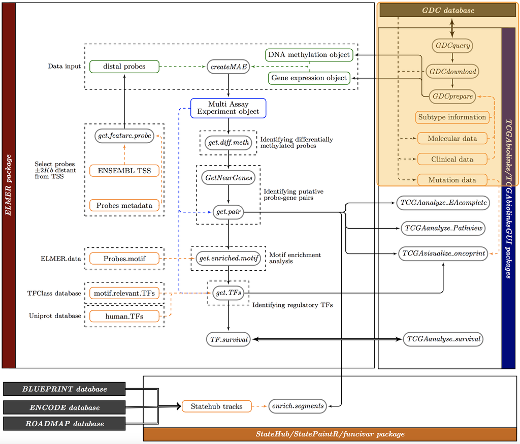

# Downloading data

## Loading required libraries

```r
library(TCGAbiolinks)
library(SummarizedExperiment)
library(DT)
library(dplyr)
```

## Gene expression

```r
query.exp <- GDCquery(project = "TCGA-LUSC",
                  data.category = "Transcriptome Profiling",
                  data.type = "Gene Expression Quantification",
                  workflow.type = "HTSeq - FPKM-UQ",
                   barcode = c("TCGA-34-5231-01","TCGA-77-7138-01"))
GDCdownload(query.exp)
exp <- GDCprepare(query = query.exp,
                          save = TRUE,
                          save.filename = "Exp_LUSC.rda",
                          summarizedExperiment = TRUE)
```

```r
exp
```

```
## class: RangedSummarizedExperiment
## dim: 57035 2
## metadata(0):
## assays(1): HTSeq - FPKM-UQ
## rownames(57035): ENSG00000000003 ENSG00000000005 ...
##   ENSG00000281912 ENSG00000281920
## rowData names(3): ensembl_gene_id external_gene_name
##   original_ensembl_gene_id
## colnames(2): TCGA-34-5231-01A-21R-1820-07
##   TCGA-77-7138-01A-41R-2045-07
## colData names(69): patient barcode ...
##   subtype_Homozygous.Deletions subtype_Expression.Subtype
```

```r
colData(exp) %>% as.data.frame %>% datatable(options = list(scrollX = TRUE), rownames = TRUE)
```

|  | patient | barcode | sample | shortLetterCode | definition | classification_of_tumor | last_known_disease_status | updated_datetime.x | primary_diagnosis | tumor_stage | age_at_diagnosis | vital_status | morphology | days_to_death | days_to_last_known_disease_status | created_datetime.x | state.x | days_to_recurrence | diagnosis_id | tumor_grade | treatments | tissue_or_organ_of_origin | days_to_birth | progression_or_recurrence | prior_malignancy | site_of_resection_or_biopsy | days_to_last_follow_up | cigarettes_per_day | weight | … |
| --- | --- | --- | --- | --- | --- | --- | --- | --- | --- | --- | --- | --- | --- | --- | --- | --- | --- | --- | --- | --- | --- | --- | --- | --- | --- | --- | --- | --- | --- | --- |
| TCGA-34-5231-01A-21R-1820-07 | TCGA-34-5231 | TCGA-34-5231-01A-21R-1820-07 | TCGA-34-5231-01A | TP | Primary solid Tumor | not reported | not reported | 2017-03-04T16:44:35.784223-06:00 | c34.1 | stage ia | 26525 | dead | 8070/3 | 1984 |  |  | live |  | 82597651-b143-511a-8c9c-bb89710353f7 | not reported | {'updated_datetime': ['2017-03-04T16:43:59.646072-06:00'], 'created_datetime': [None], 'therapeutic_agents': [None], 'submitter_id': ['TCGA-34-5231_treatment'], 'treatment_id': ['ce29ac3a-fe0f-5795-af… | c34.1 | -26525 | not reported | not reported | c34.1 | 1528 | 2.73972602739726 |  | … |
| TCGA-77-7138-01A-41R-2045-07 | TCGA-77-7138 | TCGA-77-7138-01A-41R-2045-07 | TCGA-77-7138-01A | TP | Primary solid Tumor | not reported | not reported | 2017-03-04T16:44:35.784223-06:00 | c34.3 | stage ib | 24594 | dead | 8070/3 | 340 |  |  | live |  | 618232ba-50db-538c-9ffd-a3fa1129608b | not reported | {'updated_datetime': ['2017-03-04T16:43:59.646072-06:00'], 'created_datetime': [None], 'therapeutic_agents': [None], 'submitter_id': ['TCGA-77-7138_treatment'], 'treatment_id': ['1ce0abb0-1091-553e-bf… | c34.3 | -24594 | not reported | not reported | c34.3 |  | 1.0958904109589 |  | … |

```r
assay(exp)[1:5,] %>% datatable (options = list(scrollX = TRUE), rownames = TRUE)
```

|  | TCGA-34-5231-01A-21R-1820-07 | TCGA-77-7138-01A-41R-2045-07 |
| --- | --- | --- |
| ENSG00000000003 | 325223.350028 | 433110.286517 |
| ENSG00000000005 | 139.264128346 | 0 |
| ENSG00000000419 | 707569.075758 | 1428433.70575 |
| ENSG00000000457 | 65671.6456806 | 46532.8101329 |
| ENSG00000000460 | 65908.0849004 | 55409.522772 |

```r
rowRanges(exp)
```

```
## GRanges object with 57035 ranges and 3 metadata columns:
##                   seqnames                 ranges strand | ensembl_gene_id
##                      <Rle>              <IRanges>  <Rle> |     <character>
##   ENSG00000000003     chrX [100627109, 100639991]      - | ENSG00000000003
##   ENSG00000000005     chrX [100584802, 100599885]      + | ENSG00000000005
##   ENSG00000000419    chr20 [ 50934867,  50958555]      - | ENSG00000000419
##   ENSG00000000457     chr1 [169849631, 169894267]      - | ENSG00000000457
##   ENSG00000000460     chr1 [169662007, 169854080]      + | ENSG00000000460
##               ...      ...                    ...    ... .             ...
##   ENSG00000281904     chr2   [90365737, 90367699]      + | ENSG00000281904
##   ENSG00000281909    chr15   [22480439, 22484840]      - | ENSG00000281909
##   ENSG00000281910    chr16   [58559796, 58559931]      - | ENSG00000281910
##   ENSG00000281912     chr1   [45303910, 45305619]      + | ENSG00000281912
##   ENSG00000281920     chr2   [65623272, 65628424]      + | ENSG00000281920
##                   external_gene_name original_ensembl_gene_id
##                          <character>              <character>
##   ENSG00000000003             TSPAN6       ENSG00000000003.13
##   ENSG00000000005               TNMD        ENSG00000000005.5
##   ENSG00000000419               DPM1       ENSG00000000419.11
##   ENSG00000000457              SCYL3       ENSG00000000457.12
##   ENSG00000000460           C1orf112       ENSG00000000460.15
##               ...                ...                      ...
##   ENSG00000281904         AC233263.6        ENSG00000281904.1
##   ENSG00000281909         AC100757.4        ENSG00000281909.1
##   ENSG00000281910           SNORA50A        ENSG00000281910.1
##   ENSG00000281912          LINC01144        ENSG00000281912.1
##   ENSG00000281920         AC007389.5        ENSG00000281920.1
##   -------
##   seqinfo: 24 sequences from an unspecified genome; no seqlengths
```

## DNA methylation

This subsection describes how to download DNA methylation using the Bioconductor package [TCGAbiolinks](http://bioconductor.org/packages/TCGAbiolinks/) (Colaprico et al. 2016) from [NCI Genomic Data Commons (GDC) portal](https://portal.gdc.cancer.gov/). In this example, we will download DNA methylation data (Infinium HumanMethylation450 platform) for two TCGA-LUSC (TCGA Lung Squamous Cell Carcinoma) samples. GDCquery function will search in the GDC database for the information required to download the data, this information is used by the `GDCdownload` function which will request the files to GDC, those files will be compacted into a 76 MB tar.gz file. After the download is completed `GDCdownload` will uncompress the tar.gz file and move its files to a folder; the default is GDCData/(Project)/(source)/(data.category)/(data.type)), in our example, it will be `GDCdata/TCGA-LUSC/harmonized/DNA_Methylation/Methylation_Beta_Value/`

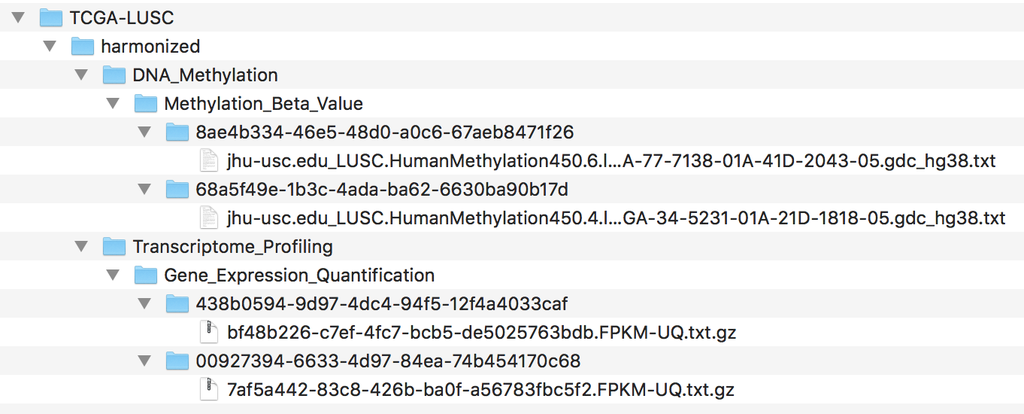

Data saved after GDCdownload is executed

Finally, `GDCprepare` transforms the downloaded data into a [summarizedExperiment](http://bioconductor.org/packages/SummarizedExperiment/) object (Huber et al. 2015) or a data frame. If *SummarizedExperiment* is set to TRUE, TCGAbiolinks will add to the object molecular sub-type information, which was defined by The Cancer Genome Atlas (TCGA) Research Network reports (the full list of papers can be seen in [TCGAquery_subtype section](http://bioconductor.org/packages/devel/bioc/vignettes/TCGAbiolinks/inst/doc/tcgaBiolinks.html#tcgaquery_subtype-working-with-molecular-subtypes-data.) in TCGAbiolinks vignette), and clinical information.

```r
query.met <- GDCquery(project = "TCGA-LUSC",
                      data.category = "DNA Methylation",
                      platform = "Illumina Human Methylation 450",
                      barcode = c("TCGA-34-5231-01A-21D-1818-05","TCGA-77-7138-01A-41D-2043-05"))
GDCdownload(query.met)
met <- GDCprepare(query = query.met,
                  save = TRUE,
                  save.filename = "DNAmethylation_LUSC.rda",
                  summarizedExperiment = TRUE)
```

```r
met
```

```
## class: RangedSummarizedExperiment
## dim: 485577 2
## metadata(0):
## assays(1): ''
## rownames(485577): cg00000029 cg00000108 ... rs966367 rs9839873
## rowData names(7): Composite.Element.REF Gene_Symbol ...
##   CGI_Coordinate Feature_Type
## colnames(2): TCGA-34-5231-01A-21D-1818-05
##   TCGA-77-7138-01A-41D-2043-05
## colData names(69): patient barcode ...
##   subtype_Homozygous.Deletions subtype_Expression.Subtype
```

```r
colData(met) %>% as.data.frame %>% datatable(options = list(scrollX = TRUE), rownames = TRUE)
```

|  | patient | barcode | sample | shortLetterCode | definition | classification_of_tumor | last_known_disease_status | updated_datetime.x | primary_diagnosis | tumor_stage | age_at_diagnosis | vital_status | morphology | days_to_death | days_to_last_known_disease_status | created_datetime.x | state.x | days_to_recurrence | diagnosis_id | tumor_grade | treatments | tissue_or_organ_of_origin | days_to_birth | progression_or_recurrence | prior_malignancy | site_of_resection_or_biopsy | days_to_last_follow_up | cigarettes_per_day | weight | … |
| --- | --- | --- | --- | --- | --- | --- | --- | --- | --- | --- | --- | --- | --- | --- | --- | --- | --- | --- | --- | --- | --- | --- | --- | --- | --- | --- | --- | --- | --- | --- |
| TCGA-34-5231-01A-21D-1818-05 | TCGA-34-5231 | TCGA-34-5231-01A-21D-1818-05 | TCGA-34-5231-01A | TP | Primary solid Tumor | not reported | not reported | 2017-03-04T16:44:35.784223-06:00 | c34.1 | stage ia | 26525 | dead | 8070/3 | 1984 |  |  | live |  | 82597651-b143-511a-8c9c-bb89710353f7 | not reported | {'updated_datetime': ['2017-03-04T16:43:59.646072-06:00'], 'created_datetime': [None], 'therapeutic_agents': [None], 'submitter_id': ['TCGA-34-5231_treatment'], 'treatment_id': ['ce29ac3a-fe0f-5795-af… | c34.1 | -26525 | not reported | not reported | c34.1 | 1528 | 2.73972602739726 |  | … |
| TCGA-77-7138-01A-41D-2043-05 | TCGA-77-7138 | TCGA-77-7138-01A-41D-2043-05 | TCGA-77-7138-01A | TP | Primary solid Tumor | not reported | not reported | 2017-03-04T16:44:35.784223-06:00 | c34.3 | stage ib | 24594 | dead | 8070/3 | 340 |  |  | live |  | 618232ba-50db-538c-9ffd-a3fa1129608b | not reported | {'updated_datetime': ['2017-03-04T16:43:59.646072-06:00'], 'created_datetime': [None], 'therapeutic_agents': [None], 'submitter_id': ['TCGA-77-7138_treatment'], 'treatment_id': ['1ce0abb0-1091-553e-bf… | c34.3 | -24594 | not reported | not reported | c34.3 |  | 1.0958904109589 |  | … |

```r
assay(met)[1:5,] %>% datatable (options = list(scrollX = TRUE), rownames = TRUE)
```

|  | TCGA-34-5231-01A-21D-1818-05 | TCGA-77-7138-01A-41D-2043-05 |
| --- | --- | --- |
| cg00000029 | 0.16905383694746 | 0.339595556132096 |
| cg00000108 |  |  |
| cg00000109 |  |  |
| cg00000165 | 0.438873007072102 | 0.182698471914805 |
| cg00000236 | 0.912404023561252 | 0.834794933990031 |

```r
rowRanges(met)
```

```
## GRanges object with 485577 ranges and 7 metadata columns:
##              seqnames                 ranges strand |
##                 <Rle>              <IRanges>  <Rle> |
##   cg00000029    chr16 [ 53434200,  53434201]      * |
##   cg00000108     chr3 [ 37417715,  37417716]      * |
##   cg00000109     chr3 [172198247, 172198248]      * |
##   cg00000165     chr1 [ 90729117,  90729118]      * |
##   cg00000236     chr8 [ 42405776,  42405777]      * |
##          ...      ...                    ...    ... .
##    rs9363764     chr6   [67522149, 67522149]      * |
##     rs939290     chr3   [14617359, 14617359]      * |
##     rs951295    chr15   [45707625, 45707625]      * |
##     rs966367     chr2   [12008094, 12008094]      * |
##    rs9839873     chr3   [86613005, 86613005]      * |
##              Composite.Element.REF
##                        <character>
##   cg00000029            cg00000029
##   cg00000108            cg00000108
##   cg00000109            cg00000109
##   cg00000165            cg00000165
##   cg00000236            cg00000236
##          ...                   ...
##    rs9363764             rs9363764
##     rs939290              rs939290
##     rs951295              rs951295
##     rs966367              rs966367
##    rs9839873             rs9839873
##                                                                  Gene_Symbol
##                                                                  <character>
##   cg00000029                                                  RBL2;RBL2;RBL2
##   cg00000108 C3orf35;C3orf35;C3orf35;C3orf35;C3orf35;C3orf35;C3orf35;C3orf35
##   cg00000109                       FNDC3B;FNDC3B;FNDC3B;FNDC3B;FNDC3B;FNDC3B
##   cg00000165                                                               .
##   cg00000236                                                           VDAC3
##          ...                                                             ...
##    rs9363764                                                               .
##     rs939290                                                               .
##     rs951295                                     RP11-718O11.1;RP11-718O11.1
##     rs966367                     AC096559.1;AC096559.1;AC096559.1;AC096559.1
##    rs9839873                                                               .
```

[output cut: 39 more lines]

```
##                            CGI_Coordinate Feature_Type
##                               <character>  <character>
##   cg00000029  CGI:chr16:53434489-53435297      N_Shore
##   cg00000108   CGI:chr3:37451927-37453047            .
##   cg00000109 CGI:chr3:172039703-172040934            .
##   cg00000165   CGI:chr1:90724932-90727247      S_Shore
##   cg00000236   CGI:chr8:42410918-42411241            .
##          ...                          ...          ...
##    rs9363764   CGI:chr6:68634840-68635154            .
##     rs939290   CGI:chr3:14602211-14603323            .
##     rs951295  CGI:chr15:45704255-45705206      S_Shelf
##     rs966367   CGI:chr2:11784857-11785127            .
##    rs9839873   CGI:chr3:86990460-86991366            .
##   -------
##   seqinfo: 25 sequences from an unspecified genome; no seqlengths
```

# Bibliography

Colaprico, Antonio, Tiago C. Silva, Catharina Olsen, Luciano Garofano, Claudia Cava, Davide Garolini, Thais S. Sabedot, et al. 2016. “TCGAbiolinks: An R/Bioconductor Package for Integrative Analysis of Tcga Data.” *Nucleic Acids Research* 44 (8): e71. doi:10.1093/nar/gkv1507.

Huber, Wolfgang, Vincent J Carey, Robert Gentleman, Simon Anders, Marc Carlson, Benilton S Carvalho, Hector Corrada Bravo, et al. 2015. “Orchestrating High-Throughput Genomic Analysis with Bioconductor.” *Nature Methods* 12 (2). Nature Publishing Group: 115–21.